# Diamonds Price Estimation

Cem Gürkan

1 Aralık 2017

# Diamons Price Estimation with CART - Decision Tree

In this article i’ll try to predict prices of diamonds using decision trees. *diamonds* Dataset is used in tidyverse package.  
CART modeling method is used for predicting prices. Materials used in this article refered at the refences section.

## Exploratory Data Analysis

```r
library(tidyverse) #For data manipulation
library(rpart) #To construct CART models
library(rpart.plot)
library(rattle)
```

Diamond dataset is containing the prices and other attributes of diamonds such as carat, clarity etc.

Dataset contains 53940 obversations and 10 variables.

## Structure of Dataset

```r
glimpse(diamonds)
```

```
## Observations: 53,940
## Variables: 10
## $ carat   <dbl> 0.23, 0.21, 0.23, 0.29, 0.31, 0.24, 0.24, 0.26, 0.22, ...
## $ cut     <ord> Ideal, Premium, Good, Premium, Good, Very Good, Very G...
## $ color   <ord> E, E, E, I, J, J, I, H, E, H, J, J, F, J, E, E, I, J, ...
## $ clarity <ord> SI2, SI1, VS1, VS2, SI2, VVS2, VVS1, SI1, VS2, VS1, SI...
## $ depth   <dbl> 61.5, 59.8, 56.9, 62.4, 63.3, 62.8, 62.3, 61.9, 65.1, ...
## $ table   <dbl> 55, 61, 65, 58, 58, 57, 57, 55, 61, 61, 55, 56, 61, 54...
## $ price   <int> 326, 326, 327, 334, 335, 336, 336, 337, 337, 338, 339,...
## $ x       <dbl> 3.95, 3.89, 4.05, 4.20, 4.34, 3.94, 3.95, 4.07, 3.87, ...
## $ y       <dbl> 3.98, 3.84, 4.07, 4.23, 4.35, 3.96, 3.98, 4.11, 3.78, ...
## $ z       <dbl> 2.43, 2.31, 2.31, 2.63, 2.75, 2.48, 2.47, 2.53, 2.49, ...
```

### Description of each variables

| Variables | Description |
| --- | --- |
| carat | weight of the diamond (0.2–5.01) |
| cut | quality of the cut (Fair, Good, Very Good, Premium, Ideal) |
| color | diamond colour, from J (worst) to D (best) |
| clarity | a measurement of how clear the diamond is (I1 (worst), SI2, SI1, VS2, VS1, VVS2, VVS1, IF (best)) |
| depth | total depth percentage = z / mean(x, y) = 2 * z / (x + y) (43–79) |
| table | width of top of diamond relative to widest point (43–95) |
| price | price in US dollars ($326–$18,823) |
| x | length in mm (0–10.74) |
| y | width in mm (0–58.9) |
| z | depth in mm (0–31.8) |

Let’s summarize the dataset and show first 10 obversation

```r
summary(diamonds)
```

```
##      carat               cut        color        clarity
##  Min.   :0.2000   Fair     : 1610   D: 6775   SI1    :13065
##  1st Qu.:0.4000   Good     : 4906   E: 9797   VS2    :12258
##  Median :0.7000   Very Good:12082   F: 9542   SI2    : 9194
##  Mean   :0.7979   Premium  :13791   G:11292   VS1    : 8171
##  3rd Qu.:1.0400   Ideal    :21551   H: 8304   VVS2   : 5066
##  Max.   :5.0100                     I: 5422   VVS1   : 3655
##                                     J: 2808   (Other): 2531
##      depth           table           price             x
##  Min.   :43.00   Min.   :43.00   Min.   :  326   Min.   : 0.000
##  1st Qu.:61.00   1st Qu.:56.00   1st Qu.:  950   1st Qu.: 4.710
##  Median :61.80   Median :57.00   Median : 2401   Median : 5.700
##  Mean   :61.75   Mean   :57.46   Mean   : 3933   Mean   : 5.731
##  3rd Qu.:62.50   3rd Qu.:59.00   3rd Qu.: 5324   3rd Qu.: 6.540
##  Max.   :79.00   Max.   :95.00   Max.   :18823   Max.   :10.740
##
##        y                z
##  Min.   : 0.000   Min.   : 0.000
##  1st Qu.: 4.720   1st Qu.: 2.910
##  Median : 5.710   Median : 3.530
##  Mean   : 5.735   Mean   : 3.539
##  3rd Qu.: 6.540   3rd Qu.: 4.040
##  Max.   :58.900   Max.   :31.800
##
```

```r
head(diamonds,10)
```

```
## # A tibble: 10 x 10
##    carat       cut color clarity depth table price     x     y     z
##    <dbl>     <ord> <ord>   <ord> <dbl> <dbl> <int> <dbl> <dbl> <dbl>
##  1  0.23     Ideal     E     SI2  61.5    55   326  3.95  3.98  2.43
##  2  0.21   Premium     E     SI1  59.8    61   326  3.89  3.84  2.31
##  3  0.23      Good     E     VS1  56.9    65   327  4.05  4.07  2.31
##  4  0.29   Premium     I     VS2  62.4    58   334  4.20  4.23  2.63
##  5  0.31      Good     J     SI2  63.3    58   335  4.34  4.35  2.75
##  6  0.24 Very Good     J    VVS2  62.8    57   336  3.94  3.96  2.48
##  7  0.24 Very Good     I    VVS1  62.3    57   336  3.95  3.98  2.47
##  8  0.26 Very Good     H     SI1  61.9    55   337  4.07  4.11  2.53
##  9  0.22      Fair     E     VS2  65.1    61   337  3.87  3.78  2.49
## 10  0.23 Very Good     H     VS1  59.4    61   338  4.00  4.05  2.39
```

## Exploring the data

### Correlation of variable with Price

If we examine the correlation of variables with price. We can see that there is strong positive correlation with x,y,z and carat. Correlation with table and depth variable is low.

```r
with(diamonds,
     data.frame(cor_x_price = cor(x, price),
                cor_y_price = cor(y, price),
                cor_z_price = cor(z, price),
                cor_depth_price = cor(depth, price),
                cor_table_price2 = cor(table, price),
                cor_carat_price3 = cor(carat, price)
     )
)
```

```
##   cor_x_price cor_y_price cor_z_price cor_depth_price cor_table_price2
## 1   0.8844352   0.8654209   0.8612494      -0.0106474        0.1271339
##   cor_carat_price3
## 1        0.9215913
```

As the carat of diamond increases price also increase as stated in correlation also. Price range is very big even at the same carat. This shows us that there are other variables that effect the price also.

[figure not shown]

```r
ggplot(diamonds) +
  geom_point(aes(x = carat, y = price), alpha = .05, color = "blue") +
  labs(title = "Diamond Price vs. Length", x = "Length of diamond (mm)", y = "Price of diamond (USD)")
```

Let’s add the clarity information to plot.

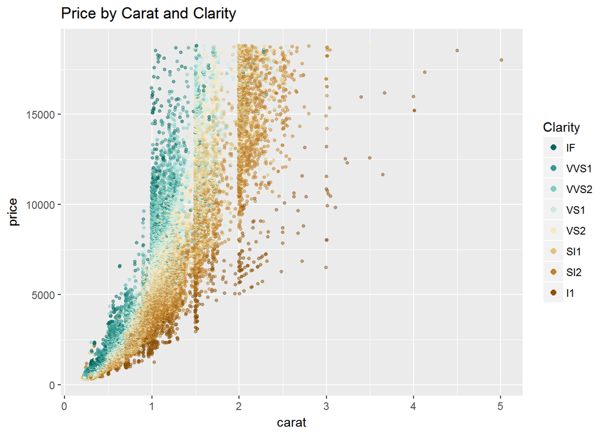

```r
ggplot(aes(x = carat, y = price), data = diamonds) +
  geom_point(alpha = 0.5, size = 1, position = 'jitter',aes(color=clarity)) +
  scale_color_brewer(type = 'div',
                     guide = guide_legend(title = 'Clarity', reverse = T,
                                          override.aes = list(alpha = 1, size = 2))) +
  ggtitle('Price by Carat and Clarity')
```

## CART modelling

First we prepare the dataset we use to train the model then test the model.

```r
set.seed(58) #Set the random seed

#Test data
diamonds_test <- diamonds %>% mutate(diamond_id = row_number()) %>%
    group_by(cut, color, clarity) %>% sample_frac(0.2) %>% ungroup()

#Train data
diamonds_train <- anti_join(diamonds %>% mutate(diamond_id = row_number()),
    diamonds_test, by = "diamond_id")
```

As there is no correlation between price and table & depth. These variables are removed.

```r
diamond_model <- rpart(price ~ x+y+z+carat+cut+color+clarity, data=diamonds_train)

summary(diamond_model)
```

```
## Call:
## rpart(formula = price ~ x + y + z + carat + cut + color + clarity,
##     data = diamonds_train)
##   n= 43143
##
##           CP nsplit rel error    xerror        xstd
## 1 0.60896855      0 1.0000000 1.0000530 0.009840248
## 2 0.18582398      1 0.3910315 0.3910476 0.004379470
## 3 0.03373935      2 0.2052075 0.2052427 0.002298806
## 4 0.02640837      3 0.1714681 0.1716709 0.002295891
## 5 0.02584292      4 0.1450598 0.1495979 0.002060551
## 6 0.01000000      5 0.1192168 0.1198359 0.001717405
##
## Variable importance
##   carat       y       x       z clarity   color
##      25      24      24      23       2       1
##
## Node number 1: 43143 observations,    complexity param=0.6089685
##   mean=3929.224, MSE=1.589526e+07
##   left son=2 (27933 obs) right son=3 (15210 obs)
##   Primary splits:
##       carat < 0.995 to the left,  improve=0.60896850, (0 missing)
##       y     < 6.345 to the left,  improve=0.60707500, (0 missing)
##       x     < 6.305 to the left,  improve=0.60380560, (0 missing)
##       z     < 3.915 to the left,  improve=0.59811950, (0 missing)
##       color splits as  LLLLRRR,   improve=0.02246444, (0 missing)
##   Surrogate splits:
##       x       < 6.275 to the left,  agree=0.984, adj=0.954, (0 split)
##       y       < 6.285 to the left,  agree=0.981, adj=0.947, (0 split)
##       z       < 3.895 to the left,  agree=0.977, adj=0.936, (0 split)
##       clarity splits as  RRLLLLLL,  agree=0.679, adj=0.090, (0 split)
##       color   splits as  LLLLLRR,   agree=0.660, adj=0.037, (0 split)
##
## Node number 2: 27933 observations,    complexity param=0.03373935
##   mean=1633.408, MSE=1247559
##   left son=4 (19914 obs) right son=5 (8019 obs)
##   Primary splits:
##       y       < 5.525 to the left,  improve=0.66395110, (0 missing)
##       carat   < 0.625 to the left,  improve=0.66358320, (0 missing)
##       x       < 5.465 to the left,  improve=0.66085580, (0 missing)
```

[output cut: 51 more lines]

```
##       carat   < 1.835 to the left,  agree=0.974, adj=0.925, (0 split)
##       z       < 4.825 to the left,  agree=0.953, adj=0.863, (0 split)
##       clarity splits as  RRLLLLLL,  agree=0.681, adj=0.082, (0 split)
##
## Node number 12: 7835 observations
##   mean=5400.087, MSE=2065554
##
## Node number 13: 2448 observations
##   mean=8516.066, MSE=5775533
##
## Node number 14: 3213 observations
##   mean=10941.86, MSE=8708725
##
## Node number 15: 1714 observations
##   mean=14923.76, MSE=6850265
```

From the summary we can see that carat, y, x and z variables are important.

Next we can draw the decision tree based on our model

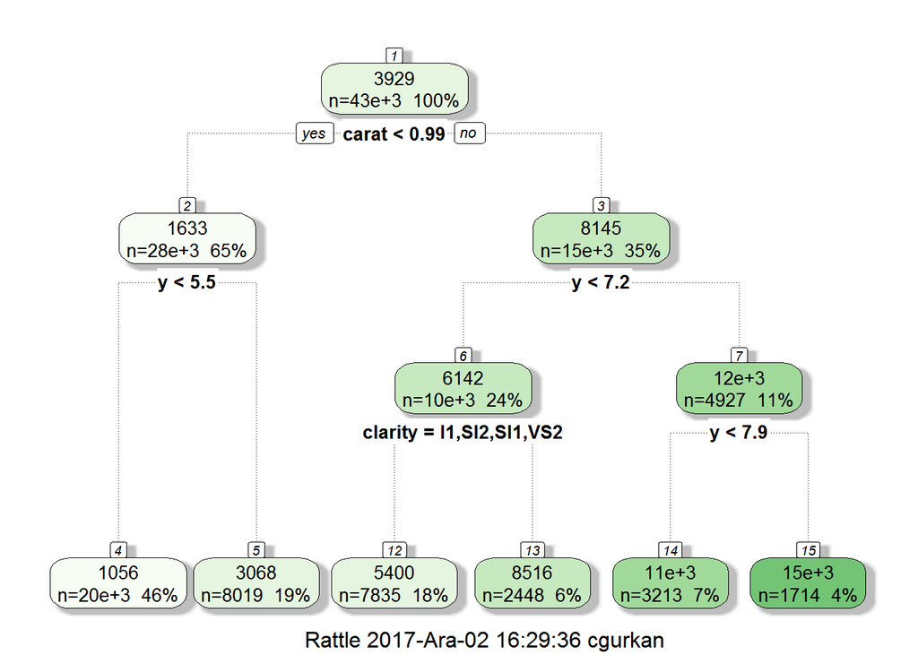

```r
fancyRpartPlot(diamond_model)
```

With decision tree we can test our model with test data.

```r
pred_Diamond_test <- predict(diamond_model, newdata = diamonds_test)
head(pred_Diamond_test,10)
```

```
##         1         2         3         4         5         6         7
## 10941.860  3067.634 10941.860  1055.871  3067.634  5400.087  3067.634
##         8         9        10
##  3067.634  3067.634  5400.087
```

```r
printcp(diamond_model)
```

```
##
## Regression tree:
## rpart(formula = price ~ x + y + z + carat + cut + color + clarity,
##     data = diamonds_train)
##
## Variables actually used in tree construction:
## [1] carat   clarity y
##
## Root node error: 6.8577e+11/43143 = 15895265
##
## n= 43143
##
##         CP nsplit rel error  xerror      xstd
## 1 0.608969      0   1.00000 1.00005 0.0098402
## 2 0.185824      1   0.39103 0.39105 0.0043795
## 3 0.033739      2   0.20521 0.20524 0.0022988
## 4 0.026408      3   0.17147 0.17167 0.0022959
## 5 0.025843      4   0.14506 0.14960 0.0020606
## 6 0.010000      5   0.11922 0.11984 0.0017174
```

```r
#Get the lowest CP value from CP table
min.xerror <- diamond_model$cptable[which.min(diamond_model$cptable[,"xerror"]),"CP"]

min.xerror
```

```
## [1] 0.01
```

Next, we prune the tree based on this value of CP:

[figure not shown]

```r
# Prune the tree
diamond_model.pruned <- prune(diamond_model, cp = min.xerror)

# Draw the prune tree
fancyRpartPlot(diamond_model.pruned)
```

Then use this prune tree to evaluate the our test data

```r
pred_Diamond_test.pruned <- predict(diamond_model.pruned, newdata = diamonds_test)
```

Obtain the pseudo R2 - a correlation.

```r
fitcorr <- format(cor(diamonds_test$price, pred_Diamond_test.pruned)^2, digits=4)

fitcorr
```

```
## [1] "0.8771"
```

## Result

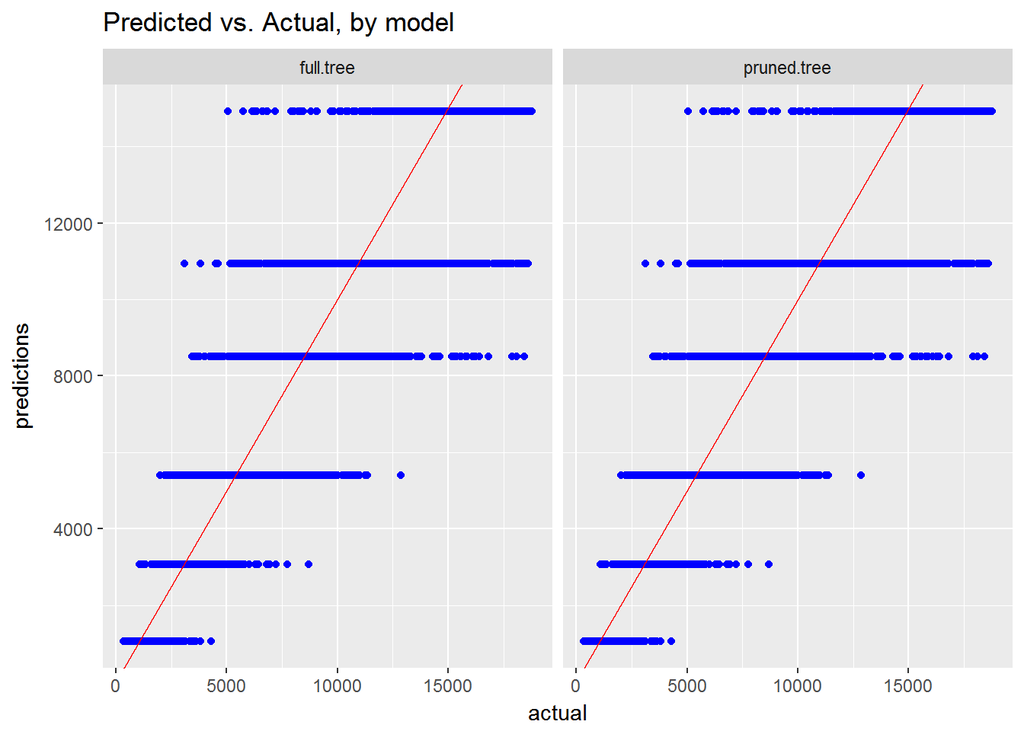

```r
# Create a data frame with the predictions for each method
all.predictions <- data.frame(actual = diamonds_test$price,
                              full.tree = pred_Diamond_test,
                              pruned.tree = pred_Diamond_test.pruned)

#For each actual create model and predictions row
all.predictions <- gather(all.predictions, key = model, value = predictions, 2:3)

# Plot "Predicted vs. actual, by model""
ggplot(data = all.predictions, aes(x = actual, y = predictions)) +
  geom_point(colour = "blue") +
  geom_abline(intercept = 0, slope = 1, colour = "red") +
  facet_wrap(~ model, ncol = 2) +
  ggtitle("Predicted vs. Actual, by model")
```

## References

1.[Modelling - predicting the amount of …](http://theanalyticalminds.blogspot.com.tr/2015/04/part-4a-modelling-predicting-amount-of.html)  
2.[A gentle introduction to decision trees using R](https://eight2late.wordpress.com/2016/02/16/a-gentle-introduction-to-decision-trees-using-r/)  
3.[An Introduction to Recursive Partitioning Using the RPART Routines](http://www.math.u-bordeaux.fr/~mchave100p/wordpress/wp-content/uploads/2013/10/longintro.pdf)  
4.[Classification and Regression Trees](https://dereksonderegger.github.io/578/8-classification-and-regression-trees.html#regression-examples)  
5.[Diamond Classification](https://rpubs.com/sarajitpoddar/diamond_classification)